# Building XGBoost Trees

Insofe

12 August 2018

# Agenda

- Read in the data
- Data Pre-processing
- Understand XGBoost Parameters
- Build an XGBoost Model
- Tune the XGBoost Model using Caret
- Report Metrics of the XGBoost model on Test Data

# Intro to Gradient Boosting

- After starting with an arbitrary constant value **y_predicted1**, we can follow the below steps to build gradient boosted trees

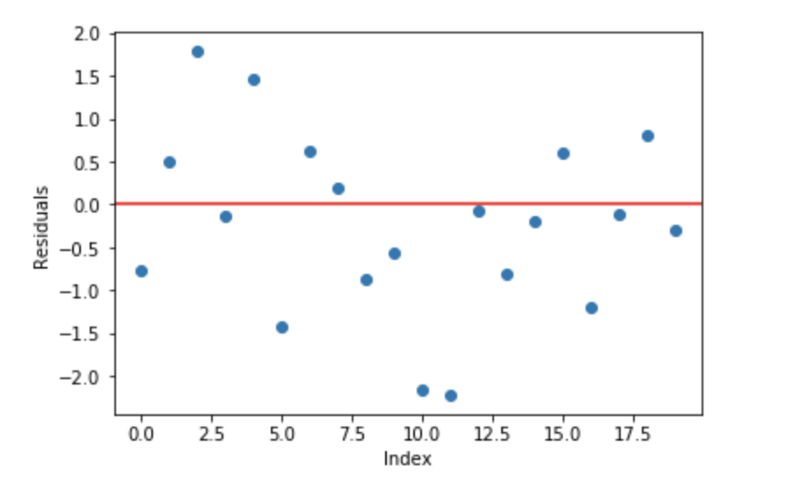

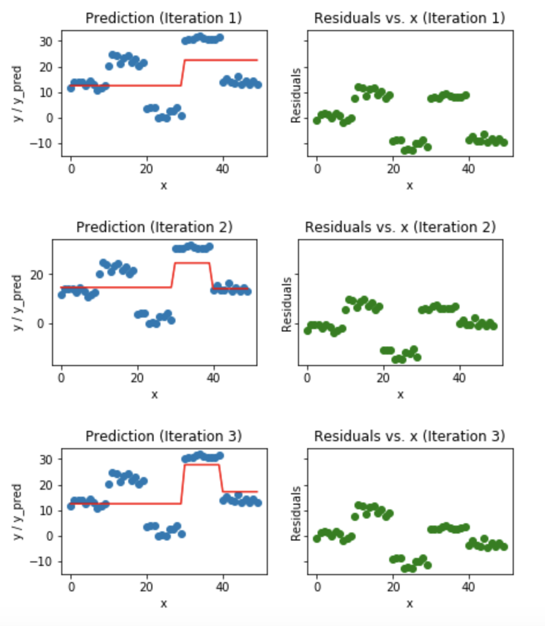

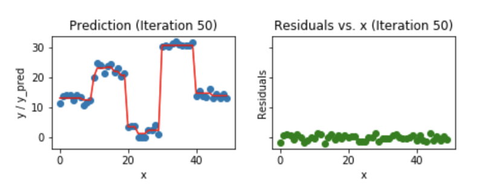

- You can find the XGBoost paper at [here](https://arxiv.org/pdf/1603.02754.pdf)

# Installation instructions

To intall xgboost on your system please follow this [link] (http://xgboost.readthedocs.io/en/latest/build.html)

# Reading & Understanding the Data

- Read in the .csv file

```r
rm(list=ls(all=T))
# change your working directory using the "setwd()" function, if your dataset is located elsewhere

gamma_data <- read.csv("gamma_data.csv")
```

- Get a feel for the data using the str(), summary() functions

```r
str(gamma_data)
```

```
## 'data.frame':    3804 obs. of  11 variables:
##  $ fLength : num  48.2 18.9 60.5 29.5 20.4 ...
##  $ fWidth  : num  17.36 16.46 33.11 22.46 9.05 ...
##  $ fSize   : num  3.03 2.44 3.19 2.63 2.34 ...
##  $ fConc   : num  0.253 0.528 0.468 0.308 0.636 ...
##  $ fConc1  : num  0.151 0.293 0.246 0.174 0.389 ...
##  $ fAsym   : num  8.57 25.13 14.3 18.12 22.27 ...
##  $ fM3Long : num  38.1 -6.54 -33.88 22.7 12.95 ...
##  $ fM3Trans: num  10.59 -16.93 28.83 13.17 -2.04 ...
##  $ fAlpha  : num  4.79 11.46 8.29 48.04 43 ...
##  $ fDist   : num  219.1 162.8 372.6 214.1 66.2 ...
##  $ class   : int  1 1 1 1 1 1 1 1 1 1 ...
```

```r
summary(gamma_data)
```

```
##     fLength            fWidth           fSize           fConc
##  Min.   :  8.052   Min.   :  0.00   Min.   :1.998   Min.   :0.0139
##  1st Qu.: 24.279   1st Qu.: 11.74   1st Qu.:2.478   1st Qu.:0.2426
##  Median : 36.640   Median : 16.85   Median :2.731   Median :0.3609
##  Mean   : 52.664   Mean   : 21.83   Mean   :2.813   Mean   :0.3854
##  3rd Qu.: 67.655   3rd Qu.: 24.18   3rd Qu.:3.087   3rd Qu.:0.5067
##  Max.   :305.422   Max.   :201.36   Max.   :4.995   Max.   :0.8757
##      fConc1           fAsym             fM3Long
##  Min.   :0.0008   Min.   :-457.916   Min.   :-331.78
##  1st Qu.:0.1315   1st Qu.: -19.215   1st Qu.: -11.55
##  Median :0.1994   Median :   4.528   Median :  15.46
##  Mean   :0.2175   Mean   :  -3.278   Mean   :  10.61
##  3rd Qu.:0.2895   3rd Qu.:  24.610   3rd Qu.:  35.44
##  Max.   :0.6283   Max.   : 473.065   Max.   : 203.86
##     fM3Trans              fAlpha           fDist             class
##  Min.   :-149.55130   Min.   : 0.000   Min.   :  1.283   Min.   :0.0000
##  1st Qu.: -10.86092   1st Qu.: 5.655   1st Qu.:140.289   1st Qu.:0.0000
##  Median :   0.00000   Median :17.665   Median :191.561   Median :1.0000
##  Mean   :   0.06309   Mean   :27.402   Mean   :192.190   Mean   :0.6554
##  3rd Qu.:  10.70800   3rd Qu.:45.189   3rd Qu.:237.785   3rd Qu.:1.0000
##  Max.   : 139.23610   Max.   :90.000   Max.   :466.408   Max.   :1.0000
```

The dataset has 3804 observations with 11 variables, the descriptions of the variables are given below :

1. **fLength** : continuous # major axis of ellipse [mm]
2. **fWidth** : continuous # minor axis of ellipse [mm]
3. **fSize** : continuous # 10-log of sum of content of all pixels [in #phot]
4. **fConc** : continuous # ratio of sum of two highest pixels over fSize [ratio]
5. **fConc1** : continuous # ratio of highest pixel over fSize [ratio]
6. **fAsym** : continuous # distance from highest pixel to center, projected onto major axis [mm]
7. **fM3Long** : continuous # 3rd root of third moment along major axis [mm]
8. **fM3Trans**: continuous # 3rd root of third moment along minor axis [mm]
9. **fAlpha** : continuous # angle of major axis with vector to origin [deg]
10. **fDist** : continuous # distance from origin to center of ellipse [mm]
11. **class** : g (0) , h (1) # gamma (signal), hadron (background)
- Let’s look at the head and tail of the dataset

```r
head(gamma_data)
```

```
##   fLength  fWidth  fSize  fConc fConc1   fAsym  fM3Long fM3Trans  fAlpha
## 1 48.2468 17.3565 3.0332 0.2529 0.1515  8.5730  38.0957  10.5868  4.7920
## 2 18.8562 16.4600 2.4385 0.5282 0.2933 25.1269  -6.5401 -16.9327 11.4610
## 3 60.4580 33.1061 3.1944 0.4679 0.2464 14.3000 -33.8765  28.8315  8.2920
## 4 29.4741 22.4581 2.6258 0.3077 0.1740 18.1242  22.7035  13.1673 48.0364
## 5 20.3836  9.0462 2.3365 0.6359 0.3894 22.2700  12.9487  -2.0403 43.0032
## 6 23.5647  9.9926 2.2095 0.5679 0.3364 30.0056 -13.8665  -8.2600 26.5328
##      fDist class
## 1 219.0870     1
## 2 162.8480     1
## 3 372.5680     1
## 4 214.1260     1
## 5  66.1667     1
## 6 185.1890     1
```

```r
tail(gamma_data)
```

```
##       fLength  fWidth  fSize  fConc fConc1     fAsym   fM3Long fM3Trans
## 3799  29.8353 11.3519 2.4449 0.4890 0.2948    9.9236   -9.0429  16.2790
## 3800 207.2530 75.8327 4.1476 0.0739 0.0371 -242.4960 -180.0290 -57.8600
## 3801 172.2442 20.1926 2.9009 0.2887 0.1940  124.5990  112.9452 -21.4436
## 3802  32.4902 10.6723 2.4742 0.4664 0.2735  -27.0097  -21.1687   8.4813
## 3803  43.2980 17.3545 2.8307 0.2877 0.1646  -60.1842  -33.8513  -3.6545
## 3804  21.3846 10.9170 2.6161 0.5857 0.3934   15.2618   11.5245   2.8766
##       fAlpha    fDist class
## 3799 17.1944 230.5486     0
## 3800 74.5740 259.3160     0
## 3801 28.9553 210.8496     0
## 3802 69.1730 120.6680     0
## 3803 78.4099 224.8299     0
## 3804  2.4229 106.8258     0
```

# Data Pre-processing

- Before we, split our dataset, let’s convert the 0 and 1 to a character factor, so that it becomes suitable for the caret train() function, caret does not generally accept classification problems where the target is a numeric 0 ir 1

```r
gamma_data$classlabel <- ifelse(gamma_data$class == 0, "g", "h")
```

- Split the dataset into train and test using using stratified sampling

```r
library(caret)
set.seed(1234)

index_train <- createDataPartition(gamma_data$class, p = 0.7, list = F)

pre_train <- gamma_data[index_train, ]

pre_test <- gamma_data[-index_train, ]
```

- Standardize all the real valued variables in the dataset using only the train data

```r
std_method <- preProcess(pre_train[, !(names(pre_train) %in% "class")], method = c("center", "scale"))

train_data <- predict(std_method, pre_train)

test_data <- predict(std_method, pre_test)
```

- Convert data into an object of the class “xgb.Dmatrix”, which works well with the xgboost model

```r
library(xgboost)
train_matrix <- xgb.DMatrix(data = as.matrix(train_data[, !(names(train_data) %in% c("class", "classlabel"))]),
                            label = as.matrix(train_data[, names(train_data) %in% "class"]))

test_matrix <- xgb.DMatrix(data = as.matrix(test_data[, !(names(test_data) %in% c("class", "classlabel"))]),
                            label = as.matrix(test_data[, names(test_data) %in% "class"]))
```

# Understanding XGBoost Parameters

- XGBoost is an efficient, scalable and regularized implementation of gradient boosting.
- Some general model parameters are given below
- The implemented base learners of most importance are:
1. linear boosted model
2. tree boosted model

```r
modelLookup("xgbLinear")
```

```
##       model parameter                 label forReg forClass probModel
## 1 xgbLinear   nrounds # Boosting Iterations   TRUE     TRUE      TRUE
## 2 xgbLinear    lambda     L2 Regularization   TRUE     TRUE      TRUE
## 3 xgbLinear     alpha     L1 Regularization   TRUE     TRUE      TRUE
## 4 xgbLinear       eta         Learning Rate   TRUE     TRUE      TRUE
```

```r
modelLookup("xgbTree")
```

```
##     model        parameter                          label forReg forClass
## 1 xgbTree          nrounds          # Boosting Iterations   TRUE     TRUE
## 2 xgbTree        max_depth                 Max Tree Depth   TRUE     TRUE
## 3 xgbTree              eta                      Shrinkage   TRUE     TRUE
## 4 xgbTree            gamma         Minimum Loss Reduction   TRUE     TRUE
## 5 xgbTree colsample_bytree     Subsample Ratio of Columns   TRUE     TRUE
## 6 xgbTree min_child_weight Minimum Sum of Instance Weight   TRUE     TRUE
## 7 xgbTree        subsample           Subsample Percentage   TRUE     TRUE
##   probModel
## 1      TRUE
## 2      TRUE
## 3      TRUE
## 4      TRUE
## 5      TRUE
## 6      TRUE
## 7      TRUE
```

```r
#names(getModelInfo())
```

# Basic XGBoost Model

```r
xgb_model_basic <- xgboost(data = train_matrix, max.depth = 2, eta = 1, nthread = -1, nround = 300, objective = "binary:logistic", verbose = 1, early_stopping_rounds = 10)
```

```
## Will train until train_error hasn't improved in 10 rounds.
##
## Stopping. Best iteration:
```

```r
xgb.save(xgb_model_basic, "xgb_model_basic")
```

```
## [1] TRUE
```

```r
rm(xgb_model_basic)

# load binary model to R
```

```r
xgb_model_basic <- xgb.load("xgb_model_basic")

basic_preds <- predict(xgb_model_basic, test_matrix)

basic_preds_labels <- ifelse(basic_preds < 0.5, 0, 1)

confusionMatrix(basic_preds_labels, test_data$class)
```

```
## Confusion Matrix and Statistics
##
##           Reference
## Prediction   0   1
##          0 282  75
##          1  98 686
##
##                Accuracy : 0.8484
##                  95% CI : (0.8262, 0.8687)
##     No Information Rate : 0.667
##     P-Value [Acc > NIR] : <2e-16
##
##                   Kappa : 0.6535
##  Mcnemar's Test P-Value : 0.0944
##
##             Sensitivity : 0.7421
##             Specificity : 0.9014
##          Pos Pred Value : 0.7899
##          Neg Pred Value : 0.8750
##              Prevalence : 0.3330
##          Detection Rate : 0.2472
##    Detection Prevalence : 0.3129
##       Balanced Accuracy : 0.8218
##
##        'Positive' Class : 0
##
```

# Build an XGBoost Model with parameters

```r
params_list <- list("objective" = "binary:logistic",
              "eta" = 0.1,
              "early_stopping_rounds" = 10,
              "max_depth" = 6,
              "gamma" = 0.5,
              "colsample_bytree" = 0.6,
              "subsample" = 0.65,
              "eval_metric" = "auc",
              "silent" = 1)
```

- gamma - A node is split only when the resulting split gives a positive reduction in the loss function. Gamma specifies the minimum loss reduction required to make a split.
- Parameters available to tune - http://xgboost.readthedocs.io/en/latest/parameter.html

```r
xgb_model_with_params <- xgboost(data = train_matrix, params = params_list, nrounds = 500, early_stopping_rounds = 20)
```

```
## Will train until train_auc hasn't improved in 20 rounds.
##
## Stopping. Best iteration:
```

```r
basic_params_preds <- predict(xgb_model_with_params, test_matrix)

basic_params_preds_labels <- ifelse(basic_params_preds < 0.5, 0, 1)

confusionMatrix(basic_params_preds_labels, test_data$class)
```

```
## Confusion Matrix and Statistics
##
##           Reference
## Prediction   0   1
##          0 277  60
##          1 103 701
##
##                Accuracy : 0.8571
##                  95% CI : (0.8355, 0.8769)
##     No Information Rate : 0.667
##     P-Value [Acc > NIR] : < 2.2e-16
##
##                   Kappa : 0.6691
##  Mcnemar's Test P-Value : 0.001003
##
##             Sensitivity : 0.7289
##             Specificity : 0.9212
##          Pos Pred Value : 0.8220
##          Neg Pred Value : 0.8719
##              Prevalence : 0.3330
##          Detection Rate : 0.2428
##    Detection Prevalence : 0.2954
##       Balanced Accuracy : 0.8251
##
##        'Positive' Class : 0
##
```

## Plotting Variable Importance

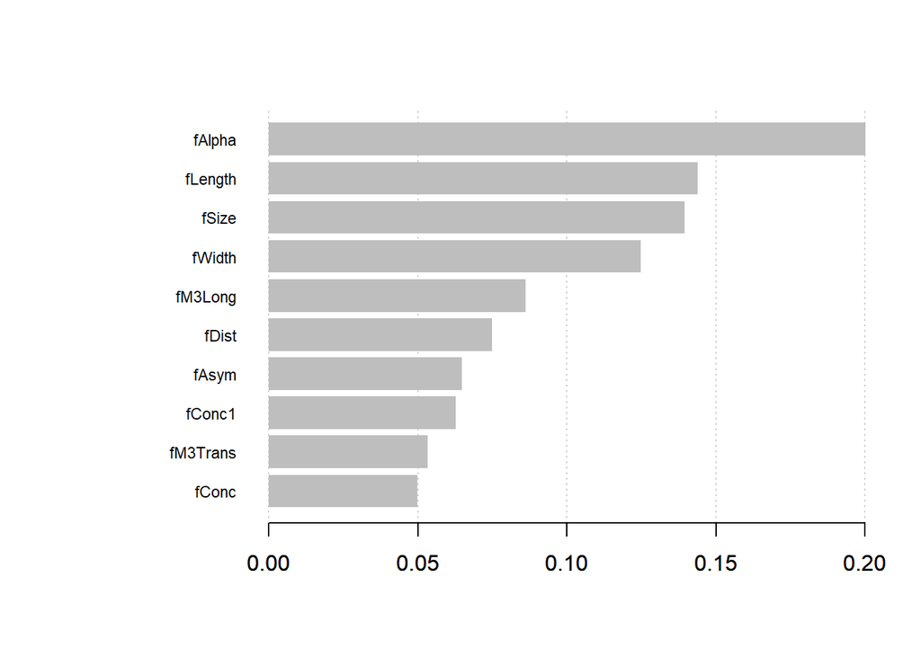

```r
variable_importance_matrix <- xgb.importance(feature_names = colnames(train_matrix), model = xgb_model_with_params)

xgb.plot.importance(variable_importance_matrix)
```

# Tuning an XGBoost Model with the caret package

```r
modelLookup("xgbTree")
```

```
##     model        parameter                          label forReg forClass
## 1 xgbTree          nrounds          # Boosting Iterations   TRUE     TRUE
## 2 xgbTree        max_depth                 Max Tree Depth   TRUE     TRUE
## 3 xgbTree              eta                      Shrinkage   TRUE     TRUE
## 4 xgbTree            gamma         Minimum Loss Reduction   TRUE     TRUE
## 5 xgbTree colsample_bytree     Subsample Ratio of Columns   TRUE     TRUE
## 6 xgbTree min_child_weight Minimum Sum of Instance Weight   TRUE     TRUE
## 7 xgbTree        subsample           Subsample Percentage   TRUE     TRUE
##   probModel
## 1      TRUE
## 2      TRUE
## 3      TRUE
## 4      TRUE
## 5      TRUE
## 6      TRUE
## 7      TRUE
```

```r
sampling_strategy <- trainControl(method = "repeatedcv", number = 5, repeats = 2, verboseIter = F, allowParallel = T)

param_grid <- expand.grid(.nrounds = c(20,30),
                          .max_depth = c(4, 6),
                          .eta =c(0.1,0.3),
                          .gamma = c(0.6, 0.5),
                          .colsample_bytree = c(0.6, 0.4),
                          .min_child_weight = 1,
                          .subsample = c(0.6, 0.9))

xgb_tuned_model <- train(x = train_data[ , !(names(train_data) %in% c("classlabel", "class"))],
                         y = train_data[ , names(train_data) %in% c("classlabel")],
                         method = "xgbTree",
                         trControl = sampling_strategy,
                         tuneGrid = param_grid)

xgb_tuned_model$bestTune
```

```
##    nrounds max_depth eta gamma colsample_bytree min_child_weight subsample
## 40      30         4 0.3   0.5              0.6                1       0.9
```

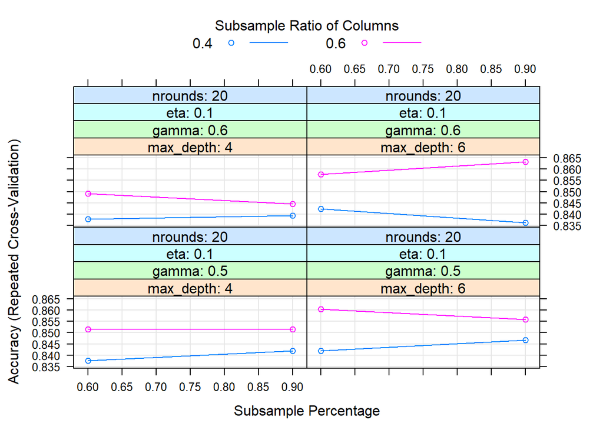

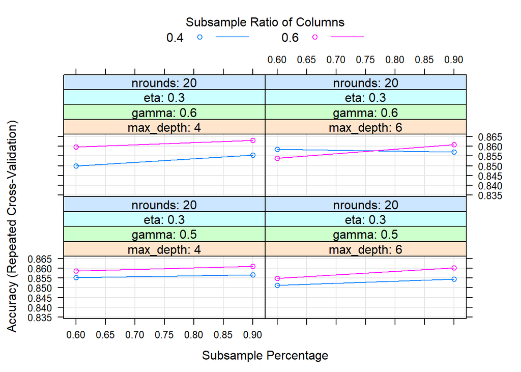

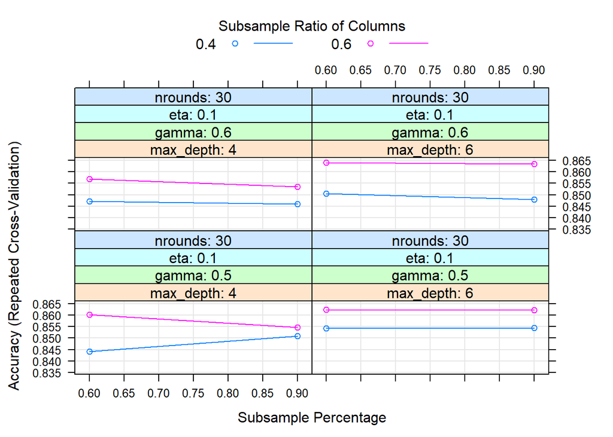

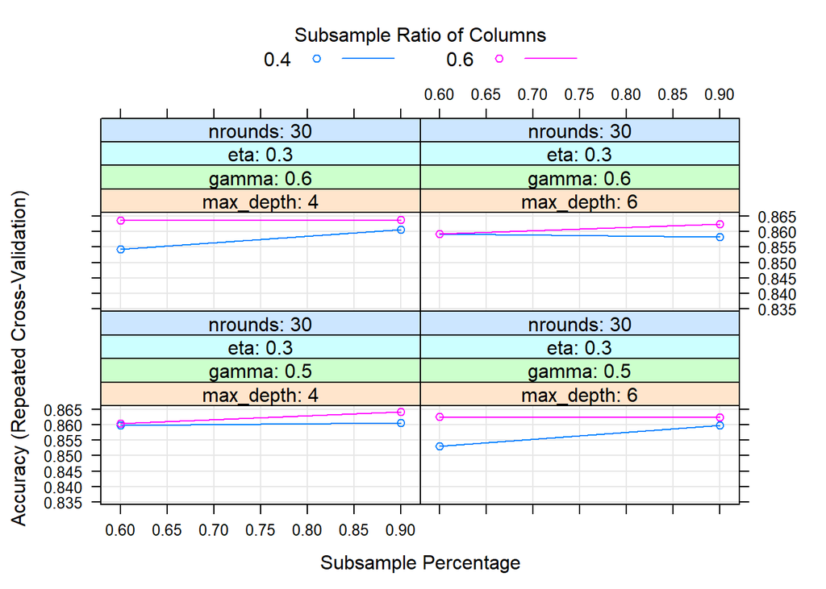

```r
plot(xgb_tuned_model)
```

- A great explanation to the min_child_weight - https://stats.stackexchange.com/questions/317073/explanation-of-min-child-weight-in-xgboost-algorithm

*Taken from the link above- min_child_weight means something like “stop trying to split once your sample size in a node goes below a given threshold”.

```r
tuned_params_preds <- predict(xgb_tuned_model, test_data[ , !(names(train_data) %in% c("classlabel", "class"))])

confusionMatrix(tuned_params_preds, test_data$classlabel)
```

```
## Confusion Matrix and Statistics
##
##           Reference
## Prediction   g   h
##          g 271  48
##          h 109 713
##
##                Accuracy : 0.8624
##                  95% CI : (0.841, 0.8819)
##     No Information Rate : 0.667
##     P-Value [Acc > NIR] : < 2.2e-16
##
##                   Kappa : 0.6773
##  Mcnemar's Test P-Value : 1.68e-06
##
##             Sensitivity : 0.7132
##             Specificity : 0.9369
##          Pos Pred Value : 0.8495
##          Neg Pred Value : 0.8674
##              Prevalence : 0.3330
##          Detection Rate : 0.2375
##    Detection Prevalence : 0.2796
##       Balanced Accuracy : 0.8250
##
##        'Positive' Class : g
##
```